# 11 Generative Adversarial Networks

**Key references**

- **GANs** — the original framework introducing the adversarial training paradigm: a generator network learns to produce realistic data by competing against a discriminator network (Goodfellow et al., 2014).
- **DCGAN** — deep convolutional GAN, which established stable architectures and training practices for image generation (Radford et al., 2016).

A **generative adversarial network** (GAN) consists of two neural networks that are trained simultaneously in competition:

- The **generator** $G$ takes random noise $\mathbf{z}$ and produces a synthetic sample $G(\mathbf{z})$.
- The **discriminator** $D$ receives either a real sample or a generated sample and tries to classify it as real or fake.

Training alternates between improving the discriminator (so it better distinguishes real from fake) and improving the generator (so its fakes become more convincing). The result is a generator that can produce realistic, novel samples from the data distribution.

## 11.1 The adversarial objective

The GAN training objective is a minimax game:

$$\min_G \max_D \; \mathbb{E}_{\mathbf{x} \sim p_{\text{data}}}\!\bigl[\log D(\mathbf{x})\bigr] + \mathbb{E}_{\mathbf{z} \sim p_{\mathbf{z}}}\!\bigl[\log\bigl(1 - D(G(\mathbf{z}))\bigr)\bigr]$$

At convergence, the generator produces samples that the discriminator cannot distinguish from real data. In practice, GANs can be difficult to train: the generator and discriminator must be balanced, and training can be unstable.

## 11.2 Architecture

The original GAN used feedforward networks for both $G$ and $D$. The **DCGAN** (Radford et al., 2016) established best practices for using convolutional architectures:

- **Generator**: uses transposed convolutions to upsample noise into an image.
- **Discriminator**: uses standard convolutions to classify images as real or fake.
- Batch normalization, LeakyReLU in the discriminator, and ReLU in the generator improve stability.

## 11.3 Code example: 1D GAN for synthetic geological profiles

```julia
using Lux, Random, Optimisers, Zygote, Statistics, Printf, CairoMakie

rng = Xoshiro(42)

# Generate training data: synthetic 1D density profiles
function make_profile(rng, n = 64)
    t = Float32.(range(0, 1, length = n))
    n_layers = rand(rng, 2:4)
    profile = zeros(Float32, n)
    boundaries = sort(rand(rng, Float32, n_layers))
    densities = 2.0f0 .+ 0.8f0 .* randn(rng, Float32, n_layers + 1)
    layer_idx = 1
    for i in 1:n
        if layer_idx <= n_layers && t[i] > boundaries[layer_idx]
            layer_idx += 1
        end
        profile[i] = densities[layer_idx]
    end
    return profile .+ 0.05f0 .* randn(rng, Float32, n)
end

prof_len = 64
n_real = 300
real_data = zeros(Float32, prof_len, n_real)
for i in 1:n_real
    real_data[:, i] = make_profile(rng, prof_len)
end
```

```julia
# Generator: noise → fake profile
latent_dim = 16
generator = Chain(
    Dense(latent_dim => 32, relu),
    Dense(32 => 64, relu),
    Dense(64 => prof_len)
)

# Discriminator: profile → real/fake probability
discriminator = Chain(
    Dense(prof_len => 32, leakyrelu),
    Dense(32 => 16, leakyrelu),
    Dense(16 => 1, sigmoid)
)

ps_g, st_g = Lux.setup(rng, generator)
ps_d, st_d = Lux.setup(rng, discriminator)
```

[output not shown]

```julia
opt_g = Adam(0.0002f0)
opt_d = Adam(0.0002f0)
opt_state_g = Optimisers.setup(opt_g, ps_g)
opt_state_d = Optimisers.setup(opt_d, ps_d)

ε = 1.0f-7

for epoch in 1:600
    # Sample noise and real data
    z = randn(rng, Float32, latent_dim, n_real)

    # --- Train discriminator ---
    (d_loss, (st_d_new, st_g_new)), d_grads = Zygote.withgradient(ps_d) do pd
        fake, st_g_ = generator(z, ps_g, st_g)
        real_pred, st_d1 = discriminator(real_data, pd, st_d)
        fake_pred, st_d2 = discriminator(fake, pd, st_d1)
        loss = -mean(log.(real_pred .+ ε) .+ log.(1 .- fake_pred .+ ε))
        (loss, (st_d2, st_g_))
    end
    opt_state_d, ps_d = Optimisers.update(opt_state_d, ps_d, d_grads[1])
    st_d = st_d_new

    # --- Train generator ---
    z2 = randn(rng, Float32, latent_dim, n_real)
    (g_loss, (st_g_new2, st_d_new2)), g_grads = Zygote.withgradient(ps_g) do pg
        fake, st_g_ = generator(z2, pg, st_g)
        fake_pred, st_d_ = discriminator(fake, ps_d, st_d)
        loss = -mean(log.(fake_pred .+ ε))
        (loss, (st_g_, st_d_))
    end
    opt_state_g, ps_g = Optimisers.update(opt_state_g, ps_g, g_grads[1])
    st_g = st_g_new2

    if epoch == 1 || epoch % 100 == 0
        @printf "Epoch %3d  D_loss: %.4f  G_loss: %.4f\n" epoch d_loss g_loss
    end
end
```

```
Epoch   1  D_loss: 1.4807  G_loss: 0.5402
Epoch 100  D_loss: 0.7413  G_loss: 0.8051
Epoch 200  D_loss: 0.6896  G_loss: 0.9842
Epoch 300  D_loss: 0.9826  G_loss: 0.9012
Epoch 400  D_loss: 1.1141  G_loss: 0.9516
Epoch 500  D_loss: 0.9829  G_loss: 1.0927
Epoch 600  D_loss: 1.1576  G_loss: 1.0495
```

```
Real mean/std: 2.004 / 0.843
Fake mean/std: 2.531 / 1.966
```

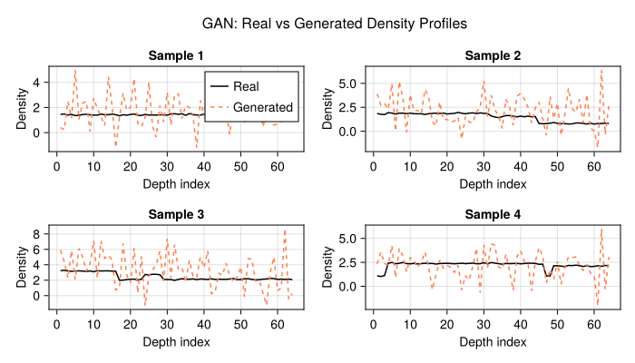

```julia
# Generate and plot some fake profiles alongside real ones
z_test = randn(rng, Float32, latent_dim, 4)
fake_profiles, _ = generator(z_test, ps_g, st_g)

# Simple distribution checks (not sufficient alone, but useful sanity checks)
z_eval = randn(rng, Float32, latent_dim, n_real)
fake_eval, _ = generator(z_eval, ps_g, st_g)
@printf "Real mean/std: %.3f / %.3f\n" mean(real_data) std(real_data)
@printf "Fake mean/std: %.3f / %.3f\n" mean(fake_eval) std(fake_eval)

fig = Figure(size = (700, 400))

for i in 1:4
    row = (i - 1) ÷ 2 + 1
    col = (i - 1) % 2 + 1
    ax = Axis(fig[row, col], title = "Sample $i",
              xlabel = "Depth index", ylabel = "Density")
    lines!(ax, real_data[:, i], color = :black, label = "Real")
    lines!(ax, fake_profiles[:, i], color = :coral, linestyle = :dash,
           label = "Generated")
    if i == 1
        axislegend(ax, position = :rt)
    end
end

Label(fig[0, :], "GAN: Real vs Generated Density Profiles",
      fontsize = 16)
fig
```

GAN quality should not be judged from one visual plot. For geoscience workflows, use multiple checks: visual realism, distribution statistics, geologically meaningful constraints, and downstream-task usefulness.

## 11.4 When to use GANs

GANs excel at **generating realistic samples** from a learned distribution. They are particularly useful when:

- You need to **augment** limited training data with realistic synthetic examples.
- You want to **sample** from a complex distribution (e.g., geological models consistent with observations).
- You need to **transfer styles** or transform between domains (e.g., converting sketches to realistic geological cross-sections).

GANs can be harder to train than other generative models (VAEs, diffusion models). Mode collapse (the generator produces only a few types of output) and training instability are common challenges.

## 11.5 Geoscience applications

- **Porous media reconstruction** — Mosser et al. (2017) used DCGANs to generate 3D micro-CT-scale porous media samples that match the statistical properties of real rock samples, enabling rapid generation of representative geological volumes for flow simulation.
- **Geostatistical inversion** — Laloy et al. (2018) used a spatial GAN as a geological prior for inverse problems, generating training-image-consistent geological models during inversion. This allows the inversion to stay within geologically realistic model space.
- **Stochastic seismic inversion** — Mosser et al. (2020) combined GANs with seismic inversion, using the generator as a geological prior to produce multiple subsurface models consistent with both seismic data and geological knowledge.
- **Geological facies modeling** — GANs have been used to generate realistic 2D and 3D geological facies models that honor well-data and geological constraints, as an alternative to traditional geostatistical simulation.

Goodfellow, I., Pouget-Abadie, J., Mirza, M., Xu, B., Warde-Farley, D., Ozair, S., Courville, A., & Bengio, Y. (2014). Generative adversarial nets. *Advances in Neural Information Processing Systems*, *27*.

Laloy, E., Hérault, R., Jacques, D., & Linde, N. (2018). Training-image based geostatistical inversion using a spatial generative adversarial neural network. *Water Resources Research*, *54*(1), 381–406. https://doi.org/10.1002/2017WR022148

Mosser, L., Dubrule, O., & Blunt, M. J. (2017). Reconstruction of three-dimensional porous media using generative adversarial neural networks. *Physical Review E*, *96*(4), 043309. https://doi.org/10.1103/PhysRevE.96.043309

Mosser, L., Dubrule, O., & Blunt, M. J. (2020). Stochastic seismic waveform inversion using generative adversarial networks as a geological prior. *Mathematical Geosciences*, *52*, 53–79. https://doi.org/10.1007/s11004-019-09832-6

Radford, A., Metz, L., & Chintala, S. (2016). Unsupervised representation learning with deep convolutional generative adversarial networks. *Proceedings of the International Conference on Learning Representations (ICLR)*. https://arxiv.org/abs/1511.06434